# CTMM Module Coyotes + Cougars

Frank Short

11/22/2021

## Continuous-Time Movement Modeling - Coyotes and Cougars of Idaho

As shown in the background literature, advancements in movement modelling have allowed for more accurate home range estimates that account for both the time dimension and autocorrelation in global position system (GPS) data. Below is an example of the implementation of the R package ctmm (Contnuous-Time Movement Modeling) to calculate the autocorrelated kernel density estimates (AKDE) of cougars (*Puma concolor*) and coyotes (*Canis latrans*) from public available movement data (Mahoney & Young, 2017). The data from this study was collected via Lotek GPS collars (Model GPS3300S; Lotek, Newmarket, ON, Canada) on cougars and coyotes in Utah and Idaho respectively. We will begin by loading in a subset of our data.

```r
library(ctmm)
library(dplyr)
library(rlist)
# Loading in data

setwd("C:/Users/fshor/OneDrive/Desktop/Project Design in BioAnthro/Create a Module")
data=read.csv("Site fidelity in cougars and coyotes, Utah_Idaho USA (data from Mahoney et al. 2016)-gps.csv")

# Creating ctmm telemetry object
data=as.telemetry(data)
```

[output not shown]

[output not shown]

[output not shown]

[output not shown]

[output not shown]

[output not shown]

[output not shown]

[output not shown]

[output not shown]

[output not shown]

[output not shown]

[output not shown]

[output not shown]

[output not shown]

[output not shown]

[output not shown]

[output not shown]

[output not shown]

[output not shown]

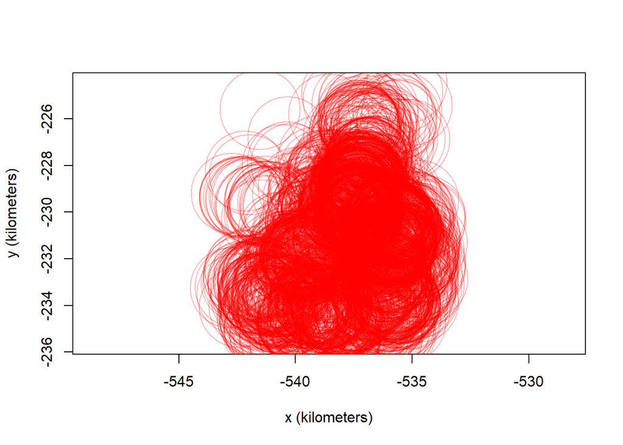

```r
data=data[c(1,4)]
data=data[-2]
plot(data[[1]])
```

Creating a raw plot of our points demonstrates the wide area occupied by this individual coyote.

## Creating and fitting models

The next step of our workflow is to create variograms from the GPS data for our individuals. Variograms represent autocorrelated data as the semi-variance between positions with varying time-lags. The structure of the variogram presents important information on the movement of an animal, as well as what method of movement modeling is best suited to the data. Arguably the most crucial element of a variogram is if the semi-variance reaches an asymptote. This indicates that an animal is range-resident, which allows our range calculation to be meaningful. Below I will create variograms for each of our individuals.

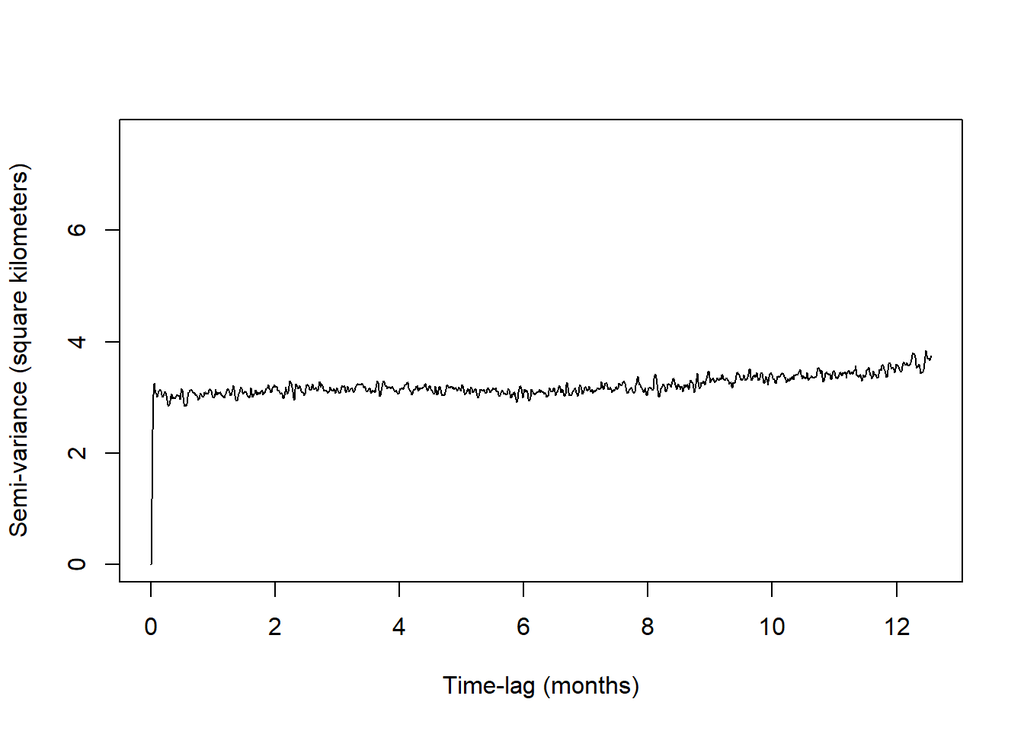

```r
dt=c(3600,10800,14400)
control=list(method="pNewton",cores=2)
proto=ctmm(error=5,circle=FALSE)
variograms=lapply(1:1,function(i) variogram(data[[i]]))
plot(variograms[[1]],fraction = 0.5)
```

## Model Fitting

```r
guess=lapply(1:1,function(i) ctmm.guess(data[[i]], CTMM=proto,variogram=variograms[[i]],interactive=FALSE))
fits<-ctmm.select(data[[1]],guess[[1]],control=control)
summary(fits)
```

```
## $name
## [1] "OUf anisotropic error"
##
## $DOF
##     mean     area    speed
## 703.7515 733.4108 160.0936
##
## $CI
##                                      low       est      high
## area (square kilometers)       53.741622 57.853420 62.114631
## t (hours)                       5.278206  5.683834  6.120635
## speed (kilometers/day)          9.964951 10.801552 11.637299
## error gps 2 [NA-HDOP] (meters)  9.335619 10.844987 12.351850
## error gps 3 [NA-HDOP] (meters) 11.337349 12.205879 13.073589
```

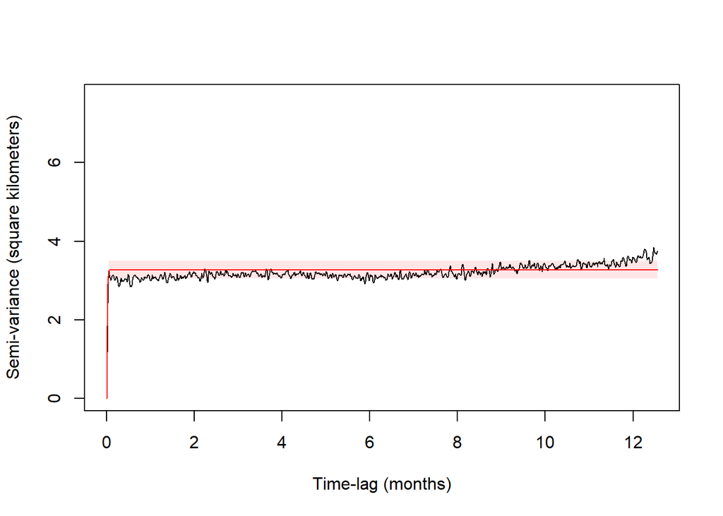

```r
#plotting variogram and fit to see accuracy
plot(variograms[[1]],CTMM=fits,fraction= 0.5)
```

Our fitted model accurately represents the data when plotted over the variogram.

## Autocorrelated Kernel Density Estimate Calculation

Now that we have fitted a continuous-time movement model, we can use this to begin calculating ecologically relevant metrics, such as home range size, range overlap, and occurrence distributions.

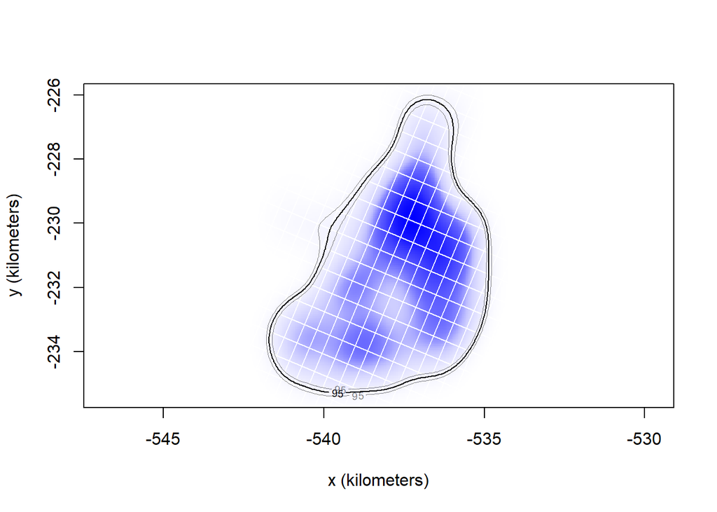

```r
#Creating monthly AKDE from fitted model
uds=lapply(1:1,function(i) akde(data[[1]], fits))

#Plotting AKDE for CO28 (coyote)
plot(uds)
```

```r
#AKDE area for CO28 (coyote)
summary(uds[[1]])
```

```
## $DOF
##      area bandwidth
##  733.4108 1939.0791
##
## $CI
##                               low      est     high
## area (square kilometers) 35.75474 38.49035 41.32537
```

Here we can see the plotted AKDE for CO28, as well as the estimated home range size.